# Homework 2

Luke Villanueva \\ MATH151A \\ 4/22/23

# Problem 1

Based on the following image,

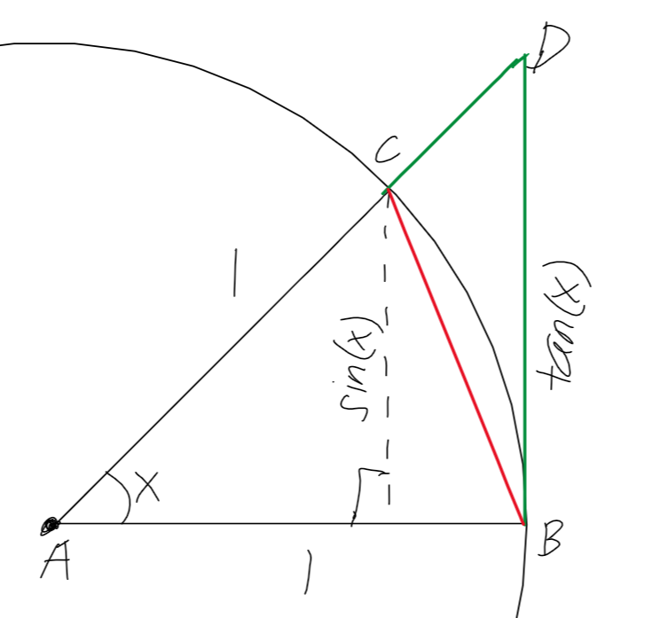

we can conclude that

\begin{gather*} \text{Area of sector } ABC = \frac{x}{2}r^{2} = \frac{x}{2} \newline sin(x) = \frac{s}{1} = s \newline \implies \text{Area of } \Delta ABC = \frac{sin(x) * 1}{2} = \frac{sin(x)}{2} \newline tan(x) = \frac{s}{1} = s \newline \implies \text{Area of } \Delta ABD = \frac{tan(x) * 1}{2} = \frac{tan(x)}{2} \newline \newline \implies \frac{sin(h)}{2} \leq \frac{h}{2} \leq \frac{tan(h)}{2} \implies \frac{sin(h)}{2} \leq \frac{h}{2} \leq \frac{\frac{sin(h)}{cos(h)}}{2} \newline \implies \frac{1}{2} \leq \frac{h}{2sin(h)} \leq \frac{1}{2cos(h)} \newline \implies 1 \leq \frac{h}{sin(h)} \leq \frac{1}{cos(h)} \newline \implies cos(h) \leq \frac{sin(h)}{h} \leq 1 \newline \text{As h } \rightarrow 0, \newline 1 \leq \frac{sin(h)}{h} \leq 1 \newline \implies \lim_{h \rightarrow 0} \frac{sin(h)}{h} = 1 \text{ by Squeeze Theorem} \end{gather*}

Because we know that $lim_{h \rightarrow 0}\frac{sin(h)}{h} = 1$, we can take the Taylor expansion of $sin(h)$ where $a = 0$ and $\varepsilon \in (0,h)$ like so:

\begin{gather*} sin(h) = \frac{sin(0)}{0!} + \frac{cos(0)}{1!}h - \frac{sin(\varepsilon)}{2!}h^{2} \newline = 0 + h - \frac{sin(\varepsilon)}{2}h^2 \newline = h(1 - \frac{sin(\varepsilon)}{2}h) \newline \implies \frac{sin(h)}{h} = 1 - \frac{sin(\varepsilon)}{2}h \newline \implies \frac{sin(h)}{h} - 1 = -\frac{sin(\varepsilon)}{2}h \newline \implies | \frac{sin(h)}{h} - 1 | = | \frac{sin(\varepsilon)}{2} | h \newline \implies | \frac{sin(h)}{h} - 1 | = Kh \newline \implies \text{By theorem, rate of convergence is } O(h) \end{gather*}